# Coursework Report

# Results

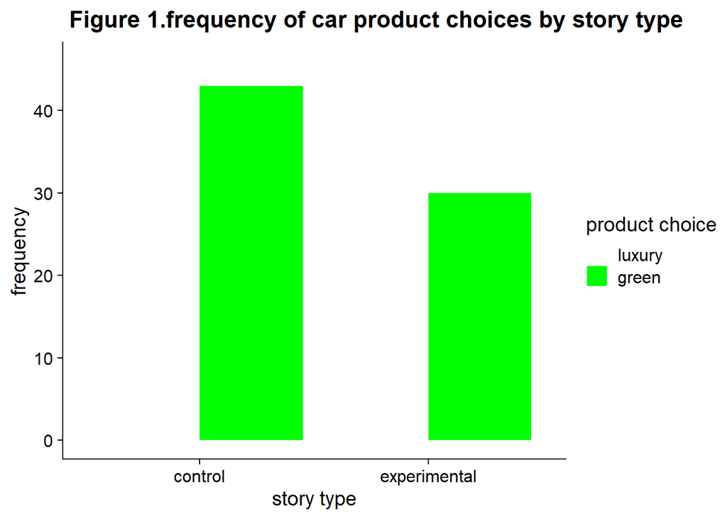

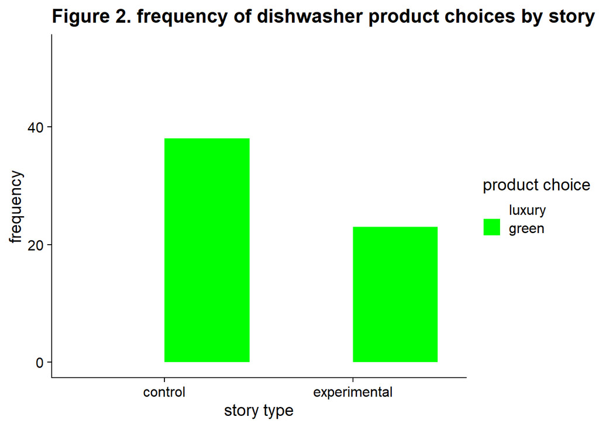

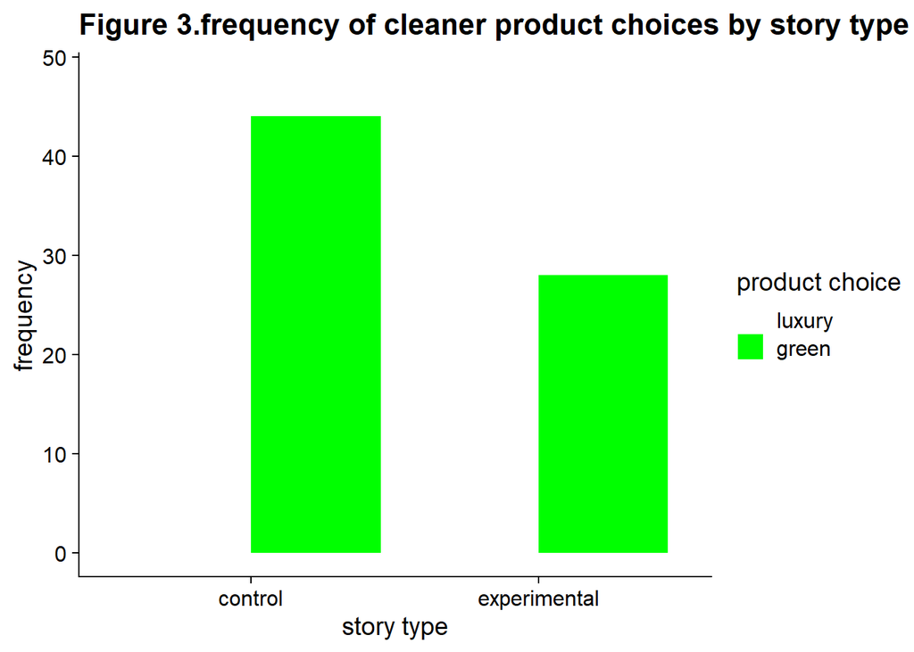

# Discussion

When concluding the results it can be interpreted that story type does not sufficiently affect product choice; this is different to our initial predictions. Instead of our predictions, this indicates that prosocial behaviour is not influenced from high-status motives or that story type does not influence high-status motives. However this cannot be determined from this research alone. The results may also suggest that greener products aren’t seen as prosocial which could be why people in the experimental condition did not choose the greener products over the luxury ones. An implication from this could be that peoples beliefs around luxury and green products could be core beliefs that are deep rooted and cannot be changed even through imagining or potentially even becoming someone of high status. This was shown as more people in the control groups chose green products without being primed to do so. A further implication is that some people may not be as considerate or aware of the environment when they make purchases, even when in this study they were prompted to think about that. This could mean that more education around the impacts of products on the environment is needed for people to make greener choices in their purchases and help save the environment. One limitation of this study is the lack of a range of participants that reflect the population as only students were recruited. A follow-up study could investigate the effects of having a sample that reflects the population and investigate the effects on results. A final limitation is that there were only 3 products to choose from which could indicate that there is not enough evidence to generalise to all products. The results from this study contradict research in this field such as Hartman and Apaolaza-Ibáñez where they examined if warm glow (the positive feeling when a person feels that they have positively impacted society) had an effect on purchases from different brands that were either green or not green. Participants were prompted with pictures of nature before suggesting their choices. This study found that the feeling of warm glow does indeed impact the decisions they make with purchases and their choice of brand (Hartman and Apaolaza-Ibáñez 2012). Another study that the results contradict is one conducted by Puska et al . They examined green organic food choices against activating status motives through memorising words associated with high status. The control condition chose 50% organic food and 70% in the experimental condition showing strong relationship with status motives and pro-green choices (Puska et al 2018), unlike our study. Future research could focus on the effect of environmental education prior to the choices on green or luxury products. This could be done as a seminar or workshop. There could also be a focus on publicly or privately declaring their choices.

# References

Griskevicius, V., Tybur, J. M., & Van den Bergh, B. (2010). Going green to be seen: status, reputation, and conspicuous conservation. Journal of personality and social psychology, 98(3), 392.

Hartmann, P., & Apaolaza-Ibáñez, V. (2012). Consumer attitude and purchase intention toward green energy brands: The roles of psychological benefits and environmental concern. Journal of business Research, 65(9), 1254-1263.

Puska, P., Kurki, S., Lähdesmäki, M., Siltaoja, M., & Luomala, H. (2018). Sweet taste of prosocial status signaling: When eating organic foods makes you happy and hopeful. Appetite, 121, 348-359.